# DGE_edgeR_pipeline_TMM

Load edgeR library

```r
library("edgeR")
```

Clean environment

```r
rm(list=ls())
```

Read in raw data

```r
BioCC_input = read.table("5_featurecounts//combined_counts.txt",sep='\t',header=TRUE)
```

Check import

```r
head(BioCC_input)
```

A data.frame: 6 × 11

|  | Geneid <chr> | length <int> | S32.IIF11.bam <int> | S33.IIF24.bam <int> | S31.IIF10.bam <int> | S28.YC10.bam <int> | S30.YC345.bam <int> | S29.YC11.bam <int> | S27.wt11.bam <int> | S26.wt10.bam <int> | S25.wt23.bam <int> |
| --- | --- | --- | --- | --- | --- | --- | --- | --- | --- | --- | --- |
| 1 | FBgn0031081 | 4851 | 7 | 7 | 19 | 7 | 5 | 10 | 6 | 15 | 12 |
| 2 | FBgn0052826 | 72 | 4 | 17 | 20 | 10 | 9 | 17 | 9 | 16 | 6 |
| 3 | FBgn0031085 | 1226 | 0 | 0 | 0 | 0 | 0 | 1 | 0 | 0 | 0 |
| 4 | FBgn0062565 | 1164 | 0 | 0 | 0 | 1 | 0 | 2 | 0 | 1 | 0 |
| 5 | FBgn0031088 | 3140 | 1 | 2 | 5 | 1 | 1 | 3 | 7 | 2 | 2 |
| 6 | FBgn0041626 | 1164 | 0 | 0 | 0 | 0 | 0 | 0 | 0 | 0 | 0 |

Turn the first column into rownames and remove gene legnth info because it is not used in this pipeline version

```r
rownames(BioCC_input) <- BioCC_input[,1]
```

```r
BioCC_input[,1:2] <- NULL
```

```r
head(BioCC_input)
```

A data.frame: 6 × 9

|  | S32.IIF11.bam <int> | S33.IIF24.bam <int> | S31.IIF10.bam <int> | S28.YC10.bam <int> | S30.YC345.bam <int> | S29.YC11.bam <int> | S27.wt11.bam <int> | S26.wt10.bam <int> | S25.wt23.bam <int> |
| --- | --- | --- | --- | --- | --- | --- | --- | --- | --- |
| FBgn0031081 | 7 | 7 | 19 | 7 | 5 | 10 | 6 | 15 | 12 |
| FBgn0052826 | 4 | 17 | 20 | 10 | 9 | 17 | 9 | 16 | 6 |
| FBgn0031085 | 0 | 0 | 0 | 0 | 0 | 1 | 0 | 0 | 0 |
| FBgn0062565 | 0 | 0 | 0 | 1 | 0 | 2 | 0 | 1 | 0 |
| FBgn0031088 | 1 | 2 | 5 | 1 | 1 | 3 | 7 | 2 | 2 |
| FBgn0041626 | 0 | 0 | 0 | 0 | 0 | 0 | 0 | 0 | 0 |

```r
ls()
```

'BioCC_input'

Filter out genes that have too many zeros (in this example, I have filtered out genes that have 7 or more zeros out of 9 samples, use what is appropriate for your dataset) and those with low expression based on global median. I have used median instead of mean because median provide a more accurate measure of centrality in situations where there are singleton outliers.

```r
BioCC_input_zero_filt <- BioCC_input[rowSums(BioCC_input == 0) <= 6,]
Medians = numeric()
for (i in 1:nrow(BioCC_input_zero_filt)){
    Medians[i] <- median(as.numeric(BioCC_input_zero_filt[i,]))
}
BioCC_final <- BioCC_input_zero_filt[Medians>=1,]
rpk <- BioCC_final
dim(rpk)
head(rpk)
```

1. 9606

2. 9

A data.frame: 6 × 9

|  | S32.IIF11.bam <int> | S33.IIF24.bam <int> | S31.IIF10.bam <int> | S28.YC10.bam <int> | S30.YC345.bam <int> | S29.YC11.bam <int> | S27.wt11.bam <int> | S26.wt10.bam <int> | S25.wt23.bam <int> |
| --- | --- | --- | --- | --- | --- | --- | --- | --- | --- |
| FBgn0031081 | 7 | 7 | 19 | 7 | 5 | 10 | 6 | 15 | 12 |
| FBgn0052826 | 4 | 17 | 20 | 10 | 9 | 17 | 9 | 16 | 6 |
| FBgn0031088 | 1 | 2 | 5 | 1 | 1 | 3 | 7 | 2 | 2 |
| FBgn0031082 | 0 | 2 | 0 | 0 | 4 | 0 | 1 | 2 | 2 |
| FBgn0053217 | 3 | 5 | 13 | 4 | 5 | 3 | 5 | 8 | 2 |
| FBgn0052350 | 3 | 2 | 5 | 4 | 1 | 1 | 1 | 10 | 1 |

Create a group vector that dictates which samples belong to what group. This is the predictor for the GLM and MUST match the order of the samples in the input data.

```r
Groups <- as.factor(c(rep("IIF",3),rep("YC",3),rep("WT",3)))
```

```r
Groups
```

1. IIF

2. IIF

3. IIF

4. YC

5. YC

6. YC

7. WT

8. WT

9. WT

**Levels**:**

1. 'IIF'

2. 'WT'

3. 'YC'

Create a DGEList object with the raw data and grouping variable

```r
rpk.norm.g <- DGEList(counts=rpk,group=Groups)
```

Calculate normalization factor to perform TMM normalization

```r
rpk.norm.g <- calcNormFactors(rpk.norm.g)
```

Calculate counts per million in case we want to do something with the numerical data (load it into SAS or run other analyses with it, etc)

```r
norm.counts.rpk.g <- cpm(rpk.norm.g)
```

```r
head(norm.counts.rpk.g)
```

A matrix: 6 × 9 of type dbl

|  | S32.IIF11.bam | S33.IIF24.bam | S31.IIF10.bam | S28.YC10.bam | S30.YC345.bam | S29.YC11.bam | S27.wt11.bam | S26.wt10.bam | S25.wt23.bam |
| --- | --- | --- | --- | --- | --- | --- | --- | --- | --- |
| FBgn0031081 | 2.1745678 | 0.9443394 | 1.6158767 | 1.3447338 | 0.8204484 | 1.6681806 | 0.7689113 | 1.5099462 | 1.8487231 |
| FBgn0052826 | 1.2426102 | 2.2933957 | 1.7009229 | 1.9210482 | 1.4768071 | 2.8359070 | 1.1533669 | 1.6106093 | 0.9243615 |
| FBgn0031088 | 0.3106525 | 0.2698113 | 0.4252307 | 0.1921048 | 0.1640897 | 0.5004542 | 0.8970631 | 0.2013262 | 0.3081205 |
| FBgn0031082 | 0.0000000 | 0.2698113 | 0.0000000 | 0.0000000 | 0.6563587 | 0.0000000 | 0.1281519 | 0.2013262 | 0.3081205 |
| FBgn0053217 | 0.9319576 | 0.6745282 | 1.1055999 | 0.7684193 | 0.8204484 | 0.5004542 | 0.6407594 | 0.8053046 | 0.3081205 |
| FBgn0052350 | 0.9319576 | 0.2698113 | 0.4252307 | 0.7684193 | 0.1640897 | 0.1668181 | 0.1281519 | 1.0066308 | 0.1540603 |

```r
dim(norm.counts.rpk.g)
```

1. 9606

2. 9

Plot MDS to determine any issues with overall variability (this is the place to identify outlier replicates). MDS is run twice, once with all genes, and once with just top 500 most variable genes)

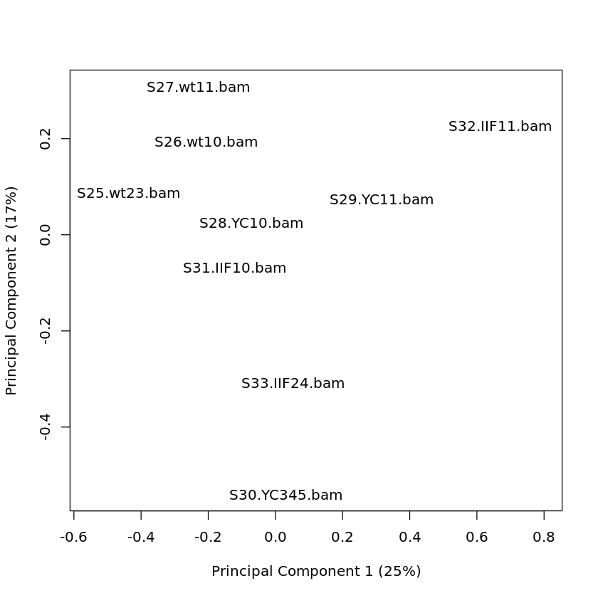

```r
plotMDS(rpk.norm.g,top=nrow(norm.counts.rpk.g),gene.selection = "common")
```

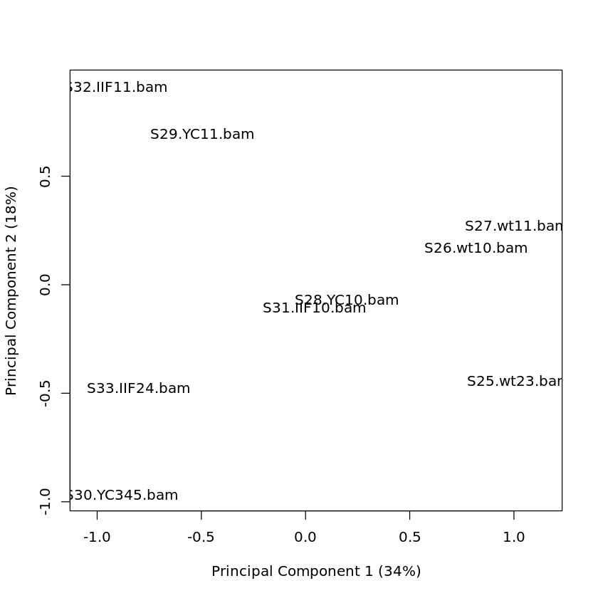

```r
plotMDS(rpk.norm.g,top=500,gene.selection = "common")
```

Create a binary design matrix for GLM framework

```r
design.mat = model.matrix(~ 0 + Groups)
```

```r
design.mat
```

A matrix: 9 × 3 of type dbl

|  | GroupsIIF | GroupsWT | GroupsYC |
| --- | --- | --- | --- |
| 1 | 1 | 0 | 0 |
| 2 | 1 | 0 | 0 |
| 3 | 1 | 0 | 0 |
| 4 | 0 | 0 | 1 |
| 5 | 0 | 0 | 1 |
| 6 | 0 | 0 | 1 |
| 7 | 0 | 1 | 0 |
| 8 | 0 | 1 | 0 |
| 9 | 0 | 1 | 0 |

Estimate the dispersion coefficient for modeling purposes (this is one of the parameters to determine the fit).

```r
rpk.norm.g <- estimateDisp(rpk.norm.g,design.mat)
```

These are additional methods for calculating dispersion

rpk.norm.g <- estimateGLMCommonDisp(rpk.norm.g,design.mat)

rpk.norm.g <- estimateGLMTrendedDisp(rpk.norm.g,design.mat,method="bin.spline")

rpk.norm.g <- estimateGLMTagwiseDisp(rpk.norm.g,design.mat)

```r
names(rpk.norm.g)
```

1. 'counts'

2. 'samples'

3. 'design'

4. 'common.dispersion'

5. 'trended.dispersion'

6. 'tagwise.dispersion'

7. 'AveLogCPM'

8. 'trend.method'

9. 'prior.df'

10. 'prior.n'

11. 'span'

```r
mean(rpk.norm.g$tagwise.dispersion)
```

0.168625299727386

Plot the biological coefficient of variation as a function of expression to detect any unusual relationships that need to be accounted for during the fitting procedure.

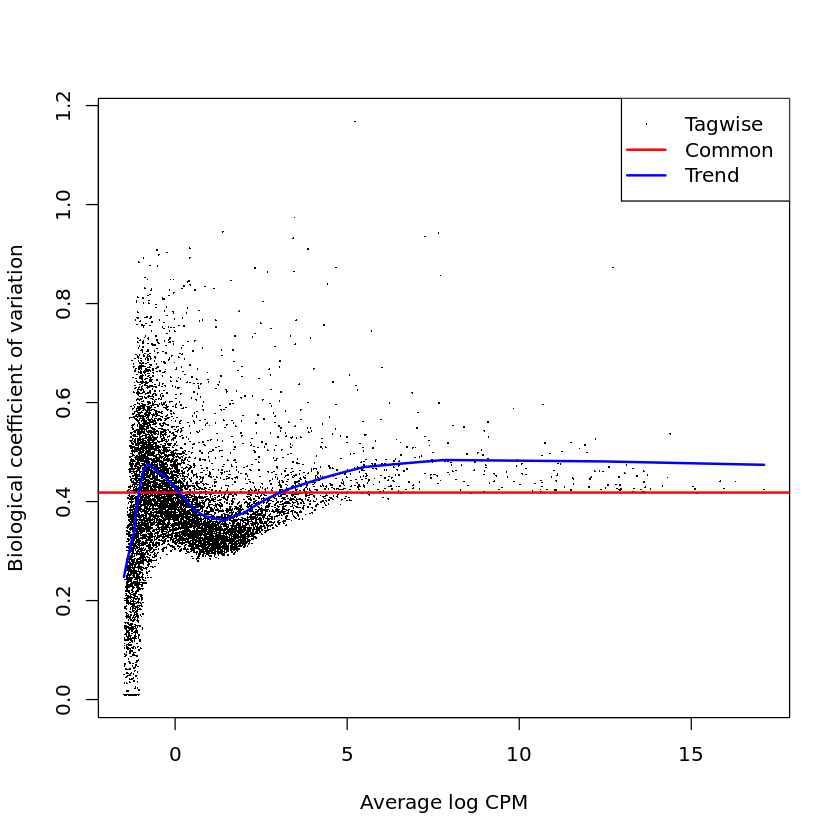

```r
plotBCV(rpk.norm.g)
```

Fit GLM framework

```r
fit <- glmFit(rpk.norm.g,design.mat)
```

Create the contrast of interest

```r
IIFvWT <- makeContrasts(GroupsIIF-GroupsWT,levels=design.mat)
```

Run likelihood ratio test to determine DE

```r
IIF_lrt <- glmLRT(fit,contrast = IIFvWT)
```

Save DE to object. n = Inf includes all of the genes.

```r
DGE_IIF_lrt <- topTags(IIF_lrt,n=Inf)
```

Look at top DE

```r
topTags(IIF_lrt)
```

**$table**

A data.frame: 10 × 5

|  | logFC <dbl> | logCPM <dbl> | LR <dbl> | PValue <dbl> | FDR <dbl> |
| --- | --- | --- | --- | --- | --- |
| FBgn0026206 | -7.900282 | 10.064565 | 107.57659 | 3.327929e-25 | 3.196808e-21 |
| FBgn0004191 | -7.416349 | 5.264352 | 101.74617 | 6.311204e-24 | 3.031271e-20 |
| FBgn0083023 | -5.015686 | 3.095213 | 71.56884 | 2.677522e-17 | 8.573425e-14 |
| FBgn0011844 | 4.807442 | 5.391176 | 57.07493 | 4.195189e-14 | 1.007475e-10 |
| FBgn0259937 | -4.066425 | 3.215191 | 52.93111 | 3.454541e-13 | 6.636864e-10 |
| FBgn0263481 | -4.502178 | 3.008764 | 51.89878 | 5.843659e-13 | 9.355698e-10 |
| FBgn0063382 | 5.522088 | 8.395362 | 48.91342 | 2.675145e-12 | 3.671063e-09 |
| FBgn0082968 | 4.908312 | 6.548549 | 44.65521 | 2.349710e-11 | 2.821414e-08 |
| FBgn0031176 | 5.152392 | 3.228066 | 43.30262 | 4.689551e-11 | 5.005314e-08 |
| FBgn0003923 | -4.510619 | 1.924145 | 42.87489 | 5.835500e-11 | 5.605581e-08 |

**$adjust.method**

'BH'

**$comparison**

'1*GroupsIIF -1*GroupsWT'

**$test**

'glm'

Calculate summary statistically significant DE

```r
summary(dt_IIF_lrt<-decideTestsDGE(IIF_lrt,p.value = 0.05))
```

```
       1*GroupsIIF -1*GroupsWT
Down                        71
NotSig                    9452
Up                          83
```

Write out the results to CSV

```r
write.csv(DGE_IIF_lrt,"BioCC_DGE_IIFvWT.csv")
```

```r
YCvWT <- makeContrasts(GroupsYC-GroupsWT,levels=design.mat)
```

```r
YC_lrt <- glmLRT(fit,contrast = YCvWT)
```

```r
DGE_YC_lrt <- topTags(YC_lrt,n=Inf)
```

```r
topTags(YC_lrt)
```

**$table**

A data.frame: 10 × 5

|  | logFC <dbl> | logCPM <dbl> | LR <dbl> | PValue <dbl> | FDR <dbl> |
| --- | --- | --- | --- | --- | --- |
| FBgn0026206 | -7.555452 | 10.0645651 | 101.50728 | 7.120125e-24 | 6.839592e-20 |
| FBgn0082968 | 6.011100 | 6.5485494 | 60.79970 | 6.318748e-15 | 3.034895e-11 |
| FBgn0030667 | 6.276493 | 0.9578739 | 55.64494 | 8.681607e-14 | 2.779851e-10 |
| FBgn0083023 | -3.932924 | 3.0952134 | 52.21305 | 4.979407e-13 | 1.195805e-09 |
| FBgn0063382 | 5.225723 | 8.3953617 | 45.03987 | 1.930632e-11 | 3.709130e-08 |
| FBgn0011844 | 4.065971 | 5.3911762 | 43.37050 | 4.529668e-11 | 7.251998e-08 |
| FBgn0261989 | 4.230331 | 4.5016584 | 42.88735 | 5.798445e-11 | 7.957124e-08 |
| FBgn0050371 | 4.951736 | 1.0333704 | 41.86219 | 9.793828e-11 | 1.175994e-07 |
| FBgn0083017 | 6.132642 | 1.0019655 | 39.91798 | 2.648536e-10 | 2.826871e-07 |
| FBgn0004191 | -3.696900 | 5.2643515 | 39.04652 | 4.138266e-10 | 3.975218e-07 |

**$adjust.method**

'BH'

**$comparison**

'-1*GroupsWT 1*GroupsYC'

**$test**

'glm'

```r
summary(dt_YC_lrt<-decideTestsDGE(YC_lrt,p.value = 0.05))
```

```
       -1*GroupsWT 1*GroupsYC
Down                       38
NotSig                   9479
Up                         89
```

```r
write.csv(DGE_YC_lrt,"BioCC_DGE_YCvWT.csv")
```

Manually check some top DE to see if makes sense by pulling the raw data

```r
BioCC_final["FBgn0026206",]
```

A data.frame: 1 × 9

|  | S32.IIF11.bam <int> | S33.IIF24.bam <int> | S31.IIF10.bam <int> | S28.YC10.bam <int> | S30.YC345.bam <int> | S29.YC11.bam <int> | S27.wt11.bam <int> | S26.wt10.bam <int> | S25.wt23.bam <int> |
| --- | --- | --- | --- | --- | --- | --- | --- | --- | --- |
| FBgn0026206 | 49 | 84 | 158 | 77 | 57 | 159 | 42061 | 25130 | 10535 |

```r
library("Vennerable")
```

Create you venn to identify overlap. The data for this was from excel comparisons (index-match combo).

```r
Venn_shared = Venn(SetNames = c("IIF vs WT","YC vs WT"),Weight = c(0,104,77,50))
```

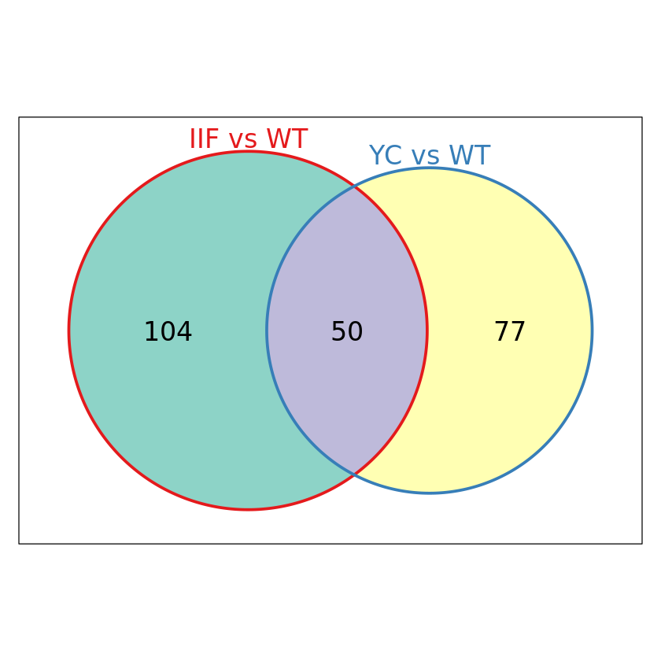

```r
plot(Venn_shared)
```

Save as PDF

```r
pdf(file="BioCC_shared_DGE.pdf")
plot(Venn_shared)
dev.off()
```

**png:** 2

Save as PNG

```r
png(file="BioCC_shared_DGE.png")
plot(Venn_shared)
dev.off()
```

**png:** 2